# Using the hierband package

Jacob Bien

2015-06-12

The `hierband` package implements the convex banding procedure for covariance estimation that is introduced in [Bien, Bunea, Xiao (2015) ``Convex Banding of the Covariance Matrix.’’ To appear in JASA](http://arxiv.org/abs/1405.6210). This document shows how the package can be used.

## Generating some data

We start by generating a $n \times p$ data matrix, whose rows are independent draws from a multivariate normal distribution with covariance matrix $\Sigma$. We take $\Sigma$ to be a $K$-banded matrix.

```r
library(hierband)
set.seed(123)
p <- 100
n <- 50
K <- 10
true <- ma(p, K)
x <- matrix(rnorm(n*p), n, p) %*% true$A
S <- cov(x)
```

Let’s look at the true covariance matrix, $\Sigma$, and the sample covariance matrix, $S$:

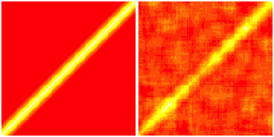

```r
par(mfrow=c(1,2),mar= rep(0.1, 4))
image(true$Sig,axes=F)
image(S, axes=F)
```

## Generating solutions along the convex banding solution path

The functiont `hierband` takes the sample covariance matrix and returns a banded matrix. It depends on a tuning parameter $\lambda$ that controls the bandwidth of the estimated matrix (which we call $\hat P_\lambda$). The function `hierband.path` gets $\hat P_\lambda$ along a (log-linear) grid of $\lambda$ values. While a user may supply this grid of $\lambda$ values (using the argument `lamlist`), a default grid is used that starts at a value of $\lambda$ for which $\hat\Sigma_\lambda$ is a diagonal matrix.

```r
library(hierband)
path <- hierband.path(S)
```

```
## 1234567891011121314151617181920
```

Let’s look at the $\hat P_\lambda$’s generated:

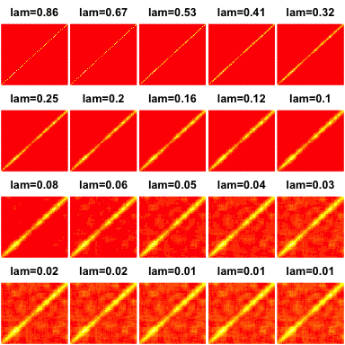

```r
par(mfrow = c(4, 5), mar = 0.1 + c(0, 0, 2, 0))
for (i in seq_along(path$lamlist))
  image(path$P[, , i], axes = F,
        main = sprintf("lam=%s", round(path$lamlist[i], 2)))
```

Sometimes one finds that all solutions are sparse, meaning that the default grid is not wide enough, i.e., we should include smaller values of $\lambda$. This can be adjusted with the parameter `flmin` (which is the ratio between the largest and smallest $\lambda$ values in the grid); also, `nlam` can be used to control the number of grid points used (the default is 20). Let’s check whether we are getting the full range of sparsity levels:

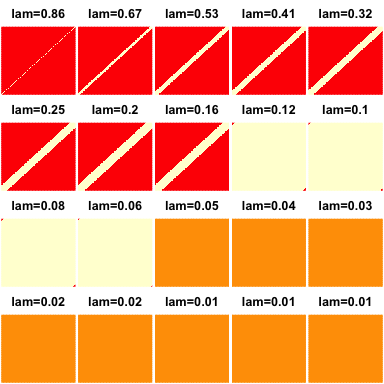

```r
par(mfrow = c(4, 5), mar = 0.1 + c(0, 0, 2, 0))
for (i in seq_along(path$lamlist))
  image(path$P[,,i] != 0, axes = F,
        main = sprintf("lam=%s", round(path$lamlist[i], 2)))
```

In this case, we see that we are getting a full spectrum of bandwidths (the last few images show that $\hat P_\lambda$ is completely dense).

## Selecting the tuning parameter

To select a value for $\lambda$, the `hierband` package provides a cross validation function. The default loss function used is squared Frobenius norm, $\|\hat P_\lambda-\Sigma\|_F^2$; however, other loss functions can be passed through the `errfun` argument.

```r
cv <- hierband.cv(path, x)
```

```
## 1234567891011121314151617181920
## 1234567891011121314151617181920
## 1234567891011121314151617181920
## 1234567891011121314151617181920
## 1234567891011121314151617181920
```

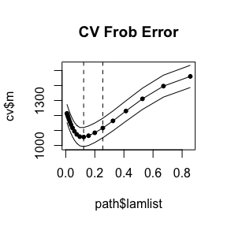

```r
fit <- hierband(S, lam = cv$lam.best)
plot(path$lamlist, cv$m, main = "CV Frob Error", type="o",
     ylim = range(cv$m - cv$se, cv$m + cv$se), pch = 20)
lines(path$lamlist, cv$m + cv$se)
lines(path$lamlist, cv$m - cv$se)
abline(v = path$lamlist[c(cv$ibest, cv$i.1se.rule)], lty = 2)
```

The two dotted lines correspond to the selected value of $\lambda$ using either the one-standard error rule ($\lambda=0.2547905$) or the minimizer of the curve ($\lambda=0.1231385$).

## How well did we do?

Since the data was simulated, we know the true covariance matrix $\Sigma$ and can check how close our estimate is to the truth and how this compares to the sample covariance matrix.

```r
sqrt(mean((fit - true$Sig)^2))
```

```
## [1] 0.08560086
```

```r
sqrt(mean((S - true$Sig)^2))
```

```
## [1] 0.1372773
```

We find that in this example we get 0.62 closer than the sample covariance matrix. Of course, this is on the basis of a single iteration. In the paper, we averaged over many iterations to get mean squared errors.

## Acknowledgment

The development of this vignette (and R package) was supported by National Science Foundation grant DMS-1405746.